# Lab 4: Multi-Layer Perceptron

Team: Mike Wisniewski

```python
import pandas as pd
import numpy as np
import sys
import matplotlib.pyplot as plt

from sklearn.model_selection import train_test_split
from sklearn.metrics import accuracy_score
from sklearn.metrics import f1_score
from sklearn.metrics import precision_score
from sklearn.metrics import recall_score
from sklearn.metrics import confusion_matrix
from sklearn.metrics import ConfusionMatrixDisplay
from sklearn.preprocessing import RobustScaler
from sklearn.preprocessing import LabelEncoder
from scipy.special import expit

%matplotlib inline
plt.style.use('ggplot')
```

> [.5 points] (1) Load the data into memory and save it to a pandas data frame. Do not normalize or one-hot encode any of the features until asked to do so later in the rubric.

```python
# read in data frame
df = pd.read_csv("acs2017_census_tract_data.csv")
```

> (2) Remove any observations that having missing data. (3) Encode any string data as integers for now. (4) You have the option of keeping the "county" variable or removing it. Be sure to discuss why you decided to keep/remove this variable.

We do not keep county because county can be an indicator for higher child poverty rates and cause bias towards our model. Unfortunately, poverty lines often correspond to county lines in real terms. Therefore, the justification is as follows: on average lower poverty rates happen in certain counties, thus we can use counties to train the model in such a way where poverty ridden counties are more likely to have a higher child povery rate. Is this begging the question? Yes. We are leading the model to an answer because we have a rough association with county vs child poverty rates. We are eliciting certain answers or responses from the model that we expect.

As a business case, we are trying to predict, by county, what the child poverty rate is. However, my justification is that the county dimension can skew the model because the model can just see what the county is for an instance and make an approximation from there. In other words, in a real world scenario, if we were to not have the county dimension we would still be able to predict with some level of accuracy.

```python
# remove missing data
df.dropna(inplace=True)

# encode string data as integers using Label Encoder on a category data type
df["State"] = LabelEncoder().fit_transform(df["State"])

# define columns that can be removed
cols_to_remove = ["TractId", "ChildPoverty", "County"]

# define categorical columns
categoricals = ["State"]

# get a list of all continuous columns
continuous = []
for column in df.columns:
    if column not in set(cols_to_remove + categoricals):
        continuous.append(column)
```

> [.5 points] Balance the dataset so that about the same number of instances are within each class. Choose a method for balancing the dataset and explain your reasoning for selecting this method. One option is to choose quantization thresholds for the "ChildPoverty" variable that equally divide the data into four classes. Should balancing of the dataset be done for both the training and testing set? Explain.

Balancing should not be done for both training and testing because balancing the testing takes away "real world" distributions for testing. It's ok to balance in training because it would allow our model to strike a better generalization when it comes to "hypothetical" examples. But when posed with unseen data (which acts as "real world" data), we must keep it as true to nature as we can. In our exercise below, we perform an even split using the qcut (quantile cut) function from pandas on Training. For testing, we use the same bins from our training split and apply them onto our testing split using the cut method - which allows us to customize how to cut our buckets.

> [.5 points] Assume you are equally interested in the classification performance for each class in the dataset. Split the dataset into 80% for training and 20% for testing. There is NO NEED to split the data multiple times for this lab.

In the following section, we split the data using an 80/20 rule. Although the class assignment said we need to split using these metrics, I think we should also justify why. We split on 80/20 because the amount of observations we have in the dataset allows us to do so. We have a sizeable amount of instances. We don't have too few where we would need to spli 90/10, and we don't have too large of a set where we can afford to split 70/30. We have roughly that middle ground of number of observations.

```python
# create X, y datasets
X = df.copy()
y = df["ChildPoverty"].copy()

# remove columns
X = X.drop(cols_to_remove, axis=1)

# split X, y into Train, Test - we use random state to preserve same split later
X_train, X_test, y_train, y_test = train_test_split(X.to_numpy(), y.to_numpy(), test_size=0.2, random_state=42)

# quantize y_train
y_train, bins = pd.qcut(y_train, q=4, labels=[0, 1, 2, 3], retbins=True)

# quantize y_test using the bins from qcut (can not create a new set of 4 cuts because then defeats the purpose of doing separately)
y_test = pd.cut(y_test, bins=bins, labels=[0, 1, 2, 3], include_lowest=True)
```

```
Class 0 Distributions for Training: 14596
Class 1 Distributions for Training: 14580
Class 2 Distributions for Training: 14476
Class 3 Distributions for Training: 14522
```

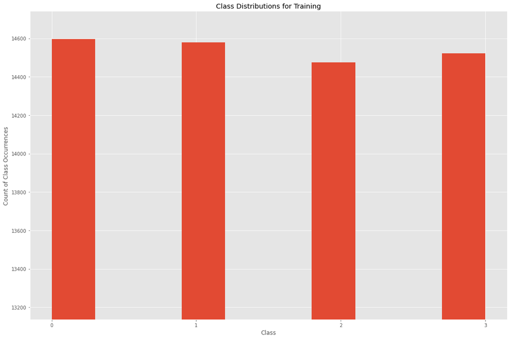

```python
# print distributions
print("Class 0 Distributions for Training:", len(y_train[y_train == 0]))
print("Class 1 Distributions for Training:", len(y_train[y_train == 1]))
print("Class 2 Distributions for Training:", len(y_train[y_train == 2]))
print("Class 3 Distributions for Training:", len(y_train[y_train == 3]))

# initialize a subplot
fig, ax = plt.subplots(figsize = (15, 10), tight_layout=True)

# plot distributions
ax.hist(y_train)

# add in titles
plt.title("Class Distributions for Training")
plt.ylabel("Count of Class Occurrences")
plt.xlabel("Class")

# modify labels
plt.xticks(y_train.unique())

# adjust y axis to show a better scale
plt.ylim(bottom=len(y_train[y_train == 0])*0.9, top=len(y_train[y_train == 0])*1.01)

plt.show()
```

As shown, there appears to be a rough number of class labels per class within the training set. This is expected. To mathematically verify this, let's take the lowest class size (class 2 at size 14,476) and divide by the largest class size (class 0 at 14,596); ~0.8% difference. Let's look at the Testing dataset to see what that distribution looks like

```
Class 0 Distributions for Training: 3633
Class 1 Distributions for Training: 3753
Class 2 Distributions for Training: 3599
Class 3 Distributions for Training: 3559
```

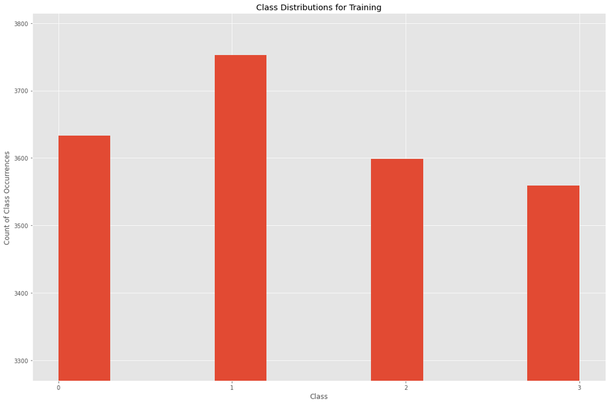

```python
# print distributions
print("Class 0 Distributions for Training:", len(y_test[y_test == 0]))
print("Class 1 Distributions for Training:", len(y_test[y_test == 1]))
print("Class 2 Distributions for Training:", len(y_test[y_test == 2]))
print("Class 3 Distributions for Training:", len(y_test[y_test == 3]))

# initialize a subplot
fig, ax = plt.subplots(figsize = (15, 10), tight_layout=True)

# plot distributions
ax.hist(y_test)

# add in titles
plt.title("Class Distributions for Training")
plt.ylabel("Count of Class Occurrences")
plt.xlabel("Class")

# modify labels
plt.xticks(y_test.unique())

# adjust y axis to show a better scale
plt.ylim(bottom=len(y_test[y_test == 0])*0.9, top=len(y_test[y_test == 0])*1.05)

plt.show()
```

This appears to be more skewed to what we would expect a real world distribution would look like. Let's calculate the difference between the smallest and larget size classes: 3559/3753 - 1 = ~5% difference. Additionally, this 5% difference occurs in the two classes we expected to be skewed (class 1 we would expect to have more observations and class 3 we expected to have fewer observations). I think this is a large enough difference to conclude that our method of cutting the classes is justified. Perhaps there can be a more refined, albeit manual method to distribute the class labels to a more real distribution - but I think this method is justified as is

> You will be using a two layer perceptron from class for the next few parts of the rubric. There are several versions of the two layer perceptron covered in class, with example code. When selecting an example two layer network from class be sure that you use:
> - [ ] (1) vectorized gradient computation
> - [ ] (2) mini-batching
> - [ ] (3) cross entropy loss
> - [ ] (4) proper Glorot initialization, at a minimum. There is no need to use momentum or learning rate reduction (assuming you choose a sufficiently small learning rate). It is recommended to use sigmoids throughout the network, but not required.

In the following section, I take code directly from the lectures and modify it accordingly. The vast majority of the code used is unchanged. I choose to keep in momentum and learning rate reduction because this helped me wrap my head around later sections where I implement adaptive learning methods. Further, keeping in momentum and learning rate reduction helped my model perform with a higher accuracy (this is not shown, just an observation I had when coding this).

```python
#Example adapted from https://github.com/rasbt/python-machine-learning-book/blob/master/code/ch12/ch12.ipynb
#Original Author: Sebastian Raschka
class TwoLayerPerceptronBase(object):
    def __init__(self, n_hidden=30, C=0.0, epochs=500, eta=0.001, random_state=None):
        np.random.seed(random_state)
        self.n_hidden = n_hidden
        self.l2_C = C
        self.epochs = epochs
        self.eta = eta

    @staticmethod
    def _encode_labels(y):
        """Encode labels into one-hot representation"""
        onehot = pd.get_dummies(y).values.T

        return onehot

    def _initialize_weights(self):
        """Initialize weights with small random numbers."""
        W1_num_elems = (self.n_features_)*self.n_hidden
        W1 = np.random.uniform(-1.0, 1.0, size=W1_num_elems)
        W1 = W1.reshape(self.n_hidden, self.n_features_) # reshape to be W
        b1 = np.zeros((self.n_hidden, 1))

        W2_num_elems = (self.n_hidden)*self.n_output_
        W2 = np.random.uniform(-1.0, 1.0, size=W2_num_elems)
        W2 = W2.reshape(self.n_output_, self.n_hidden)
        b2 = np.zeros((self.n_output_, 1))

        return W1, W2, b1, b2

    @staticmethod
    def _sigmoid(z):
        """Use scipy.special.expit to avoid overflow"""
        # 1.0 / (1.0 + np.exp(-z))
        return expit(z)


    @staticmethod
    def _L2_reg(lambda_, W1, W2):
        """Compute L2-regularization cost"""
        # only compute for non-bias terms
        return (lambda_/2.0) * np.sqrt(np.mean(W1[:, 1:] ** 2) + np.mean(W2[:, 1:] ** 2))

    def _cost(self,A3,Y_enc,W1,W2):
        '''Get the objective function value'''
        cost = np.mean((Y_enc-A3)**2)
        L2_term = self._L2_reg(self.l2_C, W1, W2)
        return cost + L2_term

    def _feedforward(self, X, W1, W2, b1, b2):
        """Compute feedforward step
        -----------
        X : Input layer with original features.
        W1: Weight matrix for input layer -> hidden layer.
        W2: Weight matrix for hidden layer -> output layer.
        ----------
        a1-a3 : activations into layer (or output layer)
        z1-z2 : layer inputs

        """
        A1 = X.T
        Z1 = W1 @ A1 + b1
        A2 = self._sigmoid(Z1)
        Z2 = W2 @ A2 + b2
        A3 = self._sigmoid(Z2)
        return A1, Z1, A2, Z2, A3

    def _get_gradient(self, A1, A2, A3, Z1, Z2, Y_enc, W1, W2):
        """ Compute gradient step using backpropagation.
        """
        # vectorized backpropagation
        V2 = -2*(Y_enc-A3)*A3*(1-A3)
        V1 = A2*(1-A2)*(W2.T @ V2)

        gradW2 = V2 @ A2.T
        gradW1 = V1 @ A1.T

        gradb2 = np.sum(V2, axis=1).reshape((-1,1))
        gradb1 = np.sum(V1, axis=1).reshape((-1,1))

        # regularize weights that are not bias terms
        gradW1 += W1 * self.l2_C
        gradW2 += W2 * self.l2_C

        return gradW1, gradW2, gradb1, gradb2

    def predict(self, X):
        """Predict class labels"""
        _, _, _, _, A3 = self._feedforward(X, self.W1, self.W2, self.b1, self.b2)
        y_pred = np.argmax(A3, axis=0)
        return y_pred
```

```python
class TLPMiniBatch(TwoLayerPerceptronBase):
    def __init__(self, alpha=0.0, decrease_const=0.0, shuffle=True, minibatches=1, **kwds):

        # need to add to the original initializer
        self.alpha = alpha
        self.decrease_const = decrease_const
        self.shuffle = shuffle
        self.minibatches = minibatches

        # but keep other keywords
        super().__init__(**kwds)


    def fit(self, X, y, print_progress=False, XY_test=None):
        """ Learn weights from training data. With mini-batch"""
        X_data, y_data = X.copy(), y.copy()
        Y_enc = self._encode_labels(y)

        # init weights and setup matrices
        self.n_features_ = X_data.shape[1]
        self.n_output_ = Y_enc.shape[0]
        self.W1, self.W2, self.b1, self.b2 = self._initialize_weights()

        # start momentum at zero for previous updates
        rho_W1_prev = np.zeros(self.W1.shape)
        rho_W2_prev = np.zeros(self.W2.shape)
        rho_b1_prev = np.zeros(self.b1.shape)
        rho_b2_prev = np.zeros(self.b2.shape)

        self.cost_ = []
        self.score_ = []
        # get starting acc
        self.score_.append(accuracy_score(y_data,self.predict(X_data)))
        # keep track of validation, if given
        # provide tuple of this
        # this tracks the health of validation
        if XY_test is not None:
            X_test = XY_test[0].copy()
            y_test = XY_test[1].copy()
            self.val_score_ = []
            self.val_score_.append(accuracy_score(y_test,self.predict(X_test)))

        for i in range(self.epochs):

            # adaptive learning rate
            eta = self.eta / (1 + self.decrease_const*i)

            if print_progress>0 and (i+1)%print_progress==0:
                sys.stderr.write('\rEpoch: %d/%d' % (i+1, self.epochs))
                sys.stderr.flush()

            if self.shuffle:
                idx_shuffle = np.random.permutation(y_data.shape[0])
                X_data, Y_enc, y_data = X_data[idx_shuffle], Y_enc[:, idx_shuffle], y_data[idx_shuffle]

            mini = np.array_split(range(y_data.shape[0]), self.minibatches)
            mini_cost = []
            for idx in mini:

                # feedforward
                A1, Z1, A2, Z2, A3 = self._feedforward(X_data[idx],
                                                       self.W1,
                                                       self.W2,
                                                       self.b1,
                                                       self.b2
                                                      )

                cost = self._cost(A3,Y_enc[:, idx],self.W1,self.W2)
                mini_cost.append(cost) # this appends cost of mini-batch only

                # compute gradient via backpropagation
                gradW1, gradW2, gradb1, gradb2 = self._get_gradient(A1=A1, A2=A2, A3=A3, Z1=Z1, Z2=Z2,
                                                  Y_enc=Y_enc[:, idx],
                                                  W1=self.W1,W2=self.W2)

                # momentum calculations
                rho_W1, rho_W2 = eta * gradW1, eta * gradW2
                rho_b1, rho_b2 = eta * gradb1, eta * gradb2
                self.W1 -= (rho_W1 + (self.alpha * rho_W1_prev)) # update with momentum
                self.W2 -= (rho_W2 + (self.alpha * rho_W2_prev)) # update with momentum
                self.b1 -= (rho_b1 + (self.alpha * rho_b1_prev))
                self.b2 -= (rho_b2 + (self.alpha * rho_b2_prev))
                rho_W1_prev, rho_W2_prev = rho_W1, rho_W2
                rho_b1_prev, rho_b2_prev = rho_b1, rho_b2


            self.cost_.append(mini_cost)
            self.score_.append(accuracy_score(y_data,self.predict(X_data)))

            # calculate the validation accuracy
            if XY_test is not None:
                self.val_score_.append(accuracy_score(y_test,self.predict(X_test)))

        return self
```

```python
class TLPMiniBatchCrossEntropy(TLPMiniBatch):
    def _cost(self,A3,Y_enc,W1,W2):
        '''Get the objective function value'''
        cost = -np.mean(np.nan_to_num((Y_enc*np.log(A3)+(1-Y_enc)*np.log(1-A3))))
        L2_term = self._L2_reg(self.l2_C, W1, W2)
        return cost + L2_term

    def _get_gradient(self, A1, A2, A3, Z1, Z2, Y_enc, W1, W2):
        """ Compute gradient step using backpropagation.
        """
        # vectorized backpropagation
        # V2 represents the cross entropy calculation (negative log likelihood)
        V2 = (A3-Y_enc) # <- this is only line that changed
        V1 = A2*(1-A2)*(W2.T @ V2)

        gradW2 = V2 @ A2.T
        gradW1 = V1 @ A1.T

        gradb2 = np.sum(V2, axis=1).reshape((-1,1))
        gradb1 = np.sum(V1, axis=1).reshape((-1,1))

        # regularize weights that are not bias terms
        gradW1 += W1 * self.l2_C
        gradW2 += W2 * self.l2_C

        return gradW1, gradW2, gradb1, gradb2
```

```python
class TLPBetterInitial(TLPMiniBatchCrossEntropy):
    def _initialize_weights(self):
        """Initialize weights Glorot and He normalization."""
        init_bound = 4*np.sqrt(6. / (self.n_hidden + self.n_features_))
        W1 = np.random.uniform(-init_bound, init_bound,(self.n_hidden, self.n_features_))

        # reduce the final layer magnitude in order to balance the size of the gradients
        # between
        init_bound = 4*np.sqrt(6 / (self.n_output_ + self.n_hidden))
        W2 = np.random.uniform(-init_bound, init_bound,(self.n_output_, self.n_hidden))

        b1 = np.zeros((self.n_hidden, 1))
        b2 = np.zeros((self.n_output_, 1))

        return W1, W2, b1, b2
```

```python
# print out accuracy results
def print_result(nn,X_train,y_train,X_test,y_test,title="",color="red"):
    print("=================")
    print(title,":")
    yhat = nn.predict(X_train)
    print('Resubstitution acc:',accuracy_score(y_train,yhat))

    yhat = nn.predict(X_test)
    accuracy = accuracy_score(y_test,yhat)
    print('Validation acc:',accuracy)

    print("Precision Score:", precision_score(y_test, yhat, average="weighted"))
    print("Recall Score:", recall_score(y_test, yhat, average="weighted"))
    print("F1 Score:", f1_score(y_test, yhat, average="weighted"))
    print("Model error:", 1 - accuracy)

    # calculate confusion matrix and plot
    cm = confusion_matrix(y_test, yhat)
    cm_disp = ConfusionMatrixDisplay(cm, display_labels=[0,1,2,3])
    cm_disp.plot()
    plt.grid(False)
    plt.show()

    if hasattr(nn,'val_score_'):
        plt.plot(range(len(nn.val_score_)), nn.val_score_, color=color,label=title)
        plt.ylabel('Validation Accuracy')
    else:
        plt.plot(range(len(nn.score_)), nn.score_, color=color,label=title)
        plt.ylabel('Resub Accuracy')

    plt.xlabel('Epochs')
    plt.tight_layout()
    plt.legend(loc='best')
    plt.grid(True)
```

Neural Network parameters should not be arbitrary - but it is difficult to correctly choose. For my parameters, I chose a more conservative approach with a low normalization parameter, a low learning rate, and a large amount of epochs. The epoch count doesn't really matter so long as it's at least 100, in my opinion. I chose 500 because my machine could handle that amount without sacrificing too much time.

For the hidden layer and all hidden layers after this, I use a rule-of-thumb approach in where the first hidden layer should be: size of the input layer * (anything between 50% and 75%) + size of the output layer. For my purposes, I choose 2/3 as my value to multiply by my input layer. All proceeding hidden layers (in later sections) will be half of the previous layer.

```python
# parameters to pass through each model - taken from class lecture
n_hidden = round(X_train.shape[1] * 2/3 + 4)
vals = {'n_hidden':n_hidden, 'C':0.01, 'epochs':500, 'eta':0.0001, 'alpha':0.001,
        'decrease_const':1e-5, 'minibatches':100, 'shuffle':True,'random_state':1}
```

> [.5 points] Use the example two-layer perceptron network from the class example and quantify performance using accuracy. Do not normalize or one-hot encode the data (not yet). Be sure that training converges by graphing the loss function versus the number of epochs.

This will be our base model. To keep comparisons apples-to-apples, all models will use the same set of parameters

```python
# initialize base model
model_base = TLPBetterInitial(**vals)

# fit base model
model_base.fit(X_train, y_train, print_progress=1, XY_test=(X_test, y_test))
```

```
Epoch: 500/500
```

```
<__main__.TLPBetterInitial at 0x2ca56cd05b0>
```

Because our model include mini batches, it is important to take the average cost for each mini batch in order to see *generally* the cost per epoch. We can see from in the below that the cost drops quickly indicating that the model is training relatively fast and that we really don't need 500 epochs to train. However, it should be noted that the magnitude of the drop is not that big. There is no real difference between 0.600 and 0.570 when it comes to cost.

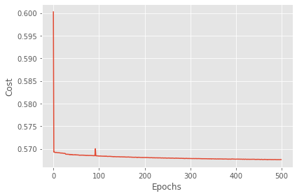

```python
# calculate the average cost
avg_cost = np.average(model_base.cost_, axis=1)

# plot cost function by epochs
plt.plot(range(len(model_base.cost_)), avg_cost)
plt.ylabel('Cost')
plt.xlabel('Epochs')
plt.tight_layout()
plt.show()
```

Validation accuracies look terrible - but as expected. Typically for model comparisons, we should not just use accuracy as out metric. This is an exception because the accuracy is not even worth discussing. For this iteration of our model, we perform so poorly because our data is not scaled or one-hot encoded.

```
=================
Validation Accuracy for Base Model :
Resubstitution acc: 0.2539794409873827
Validation acc: 0.26182618261826185
Precision Score: 0.3379672226684191
Recall Score: 0.26182618261826185
F1 Score: 0.11512646567454303
Model error: 0.7381738173817382
```

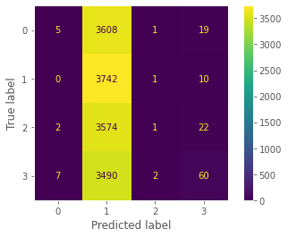

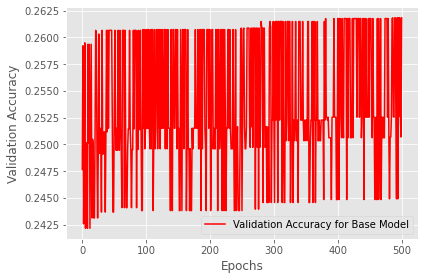

```python
# show results of base model
error_base = print_result(model_base, X_train, y_train, X_test, y_test, title="Validation Accuracy for Base Model")

# save X_train and X_test later for comparison purposes
X_train_base = X_train.copy()
X_test_base = X_test.copy()
```

> [.5 points] Now (1) normalize the continuous numeric feature data. Use the example two-layer perceptron network from the class example and quantify performance using accuracy. Be sure that training converges by graphing the loss function versus the number of epochs.

We use a robust scaler. This data is already mostly non-negative therefore we can use a standard scaling (which scales data between 0 and 1), however because this data touches on the nature of wealth inequality, we will see large differences between income, wealth, etc. To normalize these large ranges, we use a robust scaler to account for outliers.

```python
# describe the dataset to verify large ranges within dimensions
pd.options.display.max_columns = 100
df.describe()
```

|  | TractId | State | TotalPop | Men | Women | Hispanic | White | Black | Native | Asian | Pacific | VotingAgeCitizen | Income | IncomeErr | IncomePerCap | IncomePerCapErr | Poverty | ChildPoverty | Professional | Service | Office | Construction | Production | Drive | Carpool | Transit | Walk | OtherTransp | WorkAtHome | … |
| --- | --- | --- | --- | --- | --- | --- | --- | --- | --- | --- | --- | --- | --- | --- | --- | --- | --- | --- | --- | --- | --- | --- | --- | --- | --- | --- | --- | --- | --- | --- |
| count | 7.271800e+04 | 72718.000000 | 72718.000000 | 72718.000000 | 72718.000000 | 72718.000000 | 72718.000000 | 72718.000000 | 72718.000000 | 72718.000000 | 72718.000000 | 72718.000000 | 72718.000000 | 72718.000000 | 72718.000000 | 72718.000000 | 72718.000000 | 72718.000000 | 72718.000000 | 72718.000000 | 72718.000000 | 72718.000000 | 72718.000000 | 72718.000000 | 72718.000000 | 72718.000000 | 72718.000000 | 72718.000000 | 72718.000000 | … |
| mean | 2.837292e+10 | 24.340370 | 4443.485121 | 2184.362647 | 2259.122473 | 17.282951 | 61.337143 | 13.254417 | 0.727776 | 4.752459 | 0.146082 | 3141.161982 | 61119.999326 | 9690.325642 | 30666.653222 | 4249.725969 | 16.046724 | 21.148476 | 35.553813 | 18.847948 | 23.413165 | 9.263044 | 12.922312 | 75.880830 | 9.324557 | 5.370585 | 2.925778 | 1.886076 | 4.612646 | … |
| std | 1.644198e+10 | 15.102552 | 2190.183318 | 1099.954423 | 1124.604806 | 23.084428 | 30.628031 | 21.581269 | 4.505791 | 8.995573 | 1.015198 | 1512.610257 | 30511.062580 | 6119.407315 | 15844.127467 | 2991.009809 | 12.428643 | 18.572714 | 15.038790 | 7.969609 | 5.591354 | 5.943849 | 7.592511 | 14.960499 | 5.107717 | 11.626060 | 5.260623 | 2.485812 | 3.770733 | … |
| min | 1.001020e+09 | 0.000000 | 58.000000 | 26.000000 | 27.000000 | 0.000000 | 0.000000 | 0.000000 | 0.000000 | 0.000000 | 0.000000 | 40.000000 | 2692.000000 | 728.000000 | 1631.000000 | 351.000000 | 0.000000 | 0.000000 | 0.000000 | 0.000000 | 0.000000 | 0.000000 | 0.000000 | 0.000000 | 0.000000 | 0.000000 | 0.000000 | 0.000000 | 0.000000 | … |
| 25% | 1.304703e+10 | 10.000000 | 2958.000000 | 1440.000000 | 1494.000000 | 2.600000 | 38.100000 | 0.800000 | 0.000000 | 0.200000 | 0.000000 | 2096.000000 | 40380.000000 | 5737.000000 | 20624.000000 | 2508.000000 | 6.900000 | 6.200000 | 24.700000 | 13.300000 | 19.700000 | 5.000000 | 7.200000 | 72.400000 | 5.800000 | 0.000000 | 0.400000 | 0.400000 | 2.000000 | … |
| 50% | 2.804700e+10 | 24.000000 | 4137.000000 | 2024.000000 | 2102.000000 | 7.400000 | 70.500000 | 3.800000 | 0.000000 | 1.500000 | 0.000000 | 2926.000000 | 54413.000000 | 8268.000000 | 27249.000000 | 3404.000000 | 12.600000 | 16.300000 | 33.300000 | 17.700000 | 23.200000 | 8.400000 | 11.800000 | 79.900000 | 8.500000 | 1.000000 | 1.400000 | 1.200000 | 3.800000 | … |
| 75% | 4.200341e+10 | 38.000000 | 5532.750000 | 2719.000000 | 2817.000000 | 21.100000 | 87.700000 | 14.500000 | 0.400000 | 5.000000 | 0.000000 | 3923.000000 | 74688.000000 | 11909.000000 | 36413.000000 | 4959.000000 | 21.800000 | 31.600000 | 44.800000 | 23.200000 | 26.900000 | 12.500000 | 17.500000 | 84.900000 | 11.900000 | 4.600000 | 3.300000 | 2.500000 | 6.300000 | … |
| max | 7.215375e+10 | 51.000000 | 65528.000000 | 32266.000000 | 33262.000000 | 100.000000 | 100.000000 | 100.000000 | 99.400000 | 91.400000 | 71.900000 | 39389.000000 | 249750.000000 | 153365.000000 | 220253.000000 | 84414.000000 | 100.000000 | 100.000000 | 92.200000 | 70.900000 | 72.300000 | 68.100000 | 60.500000 | 100.000000 | 64.000000 | 90.800000 | 77.700000 | 53.400000 | 82.800000 | … |

```python
# initialize scaler
scaler = RobustScaler()

# normalize the continuous data
X_scale = X.copy()
X_scale[continuous] = scaler.fit_transform(X_scale[continuous])
```

```python
# split train and test and use same random split to preserve the same exact indices split
X_train, X_test = train_test_split(X_scale.to_numpy(), test_size=0.2, random_state=42)
```

```python
# initialize normalized model
model_normalized = TLPBetterInitial(**vals)

# fit normalized model
model_normalized.fit(X_train, y_train, print_progress=1, XY_test=(X_test, y_test))
```

```
Epoch: 500/500
```

```
<__main__.TLPBetterInitial at 0x2ca592a4dc0>
```

Accuracies are starting to look better. But what's important is the F1 score. An F1 score of 0.73 is generally looked at as an Ok to Good F1 score, depending on the industry. Because we had properly split our training sets to be about even, we can safely assume based on our F1 score that our model is not predicting the most popular class, because all classes are equally popular within the training set. Our confusion matrix looks decent too, relative to the previous model.

```
=================
Validation Accuracy for Normalized Model :
Resubstitution acc: 0.7307216282187919
Validation acc: 0.7262788778877888
Precision Score: 0.7317640894077239
Recall Score: 0.7262788778877888
F1 Score: 0.7280385983612554
Model error: 0.2737211221122112
```

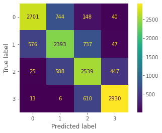

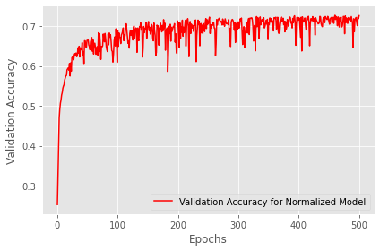

```python
# show results of normalized model
error_normalized = print_result(model_normalized, X_train, y_train, X_test, y_test, title="Validation Accuracy for Normalized Model")

# save X_train and X_test later for comparison purposes
X_train_normalized = X_train.copy()
X_test_normalized = X_test.copy()
```

> [.5 points] Now(1) normalize the continuous numeric feature data AND (2) one hot encode the categorical data. Use the example two-layer perceptron network from the class example and quantify performance using accuracy. Be sure that training converges by graphing the loss function versus the number of epochs.

We normalize on state. We would also normalize on county, but we took that out. Our only categorical dimension besides our y is State. We use a simple one hot encoding via pandas get_dummies function.

```python
# one-hot encode string columns
one_hot_state = pd.get_dummies(X_scale['State'], prefix="State")

# # drop string columns as now one-hot encoded
X_ohe = X_scale.copy()
X_ohe = X_ohe.drop('State', axis = 1)

# Join the encoded df
X_ohe = X_ohe.join(one_hot_state)
```

```python
# split train and test based on 80/20 splits - stratify the output to have even number of classes in training and testing
X_train, X_test = train_test_split(X_ohe.to_numpy(), test_size=0.2, random_state=42)
```

```python
# initialize normalized model
model_ohe = TLPBetterInitial(**vals)

# fit normalized model
model_ohe.fit(X_train, y_train, print_progress=1, XY_test=(X_test, y_test))
```

```
Epoch: 500/500
```

```
<__main__.TLPBetterInitial at 0x2ca5530d6d0>
```

One hot encoding appears to have only slightly better stats, but for the sake of report, it's basically the same model as our normalized model. This tells use that scaling our data was more important than one-hot encoding. Similar to our Normalized model, our accuracies look decent and our F1 score is passable. We are predicting classes at an accurate rate without predicting one single class in order to maximize accuracy %. The only difference is the accuracy is much more smoother with OHE, indicating that the model learned quickly.

```
=================
Validation Accuracy for Normalized and OHE Model :
Resubstitution acc: 0.7360848489015711
Validation acc: 0.7299917491749175
Precision Score: 0.7322317166279486
Recall Score: 0.7299917491749175
F1 Score: 0.7306424347985838
Model error: 0.2700082508250825
```

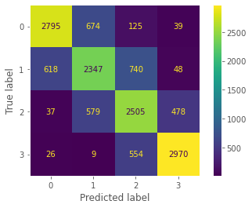

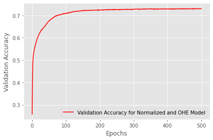

```python
# show results of normalized and scaled model
error_ohe = print_result(model_ohe, X_train, y_train, X_test, y_test, title="Validation Accuracy for Normalized and OHE Model")
```

> [1 points] Compare the performance of the three models you just trained. Are there any meaningful differences in performance? Explain, in your own words, why these models have (or do not have) different performances.

There is an obvious difference in our base model vs our normalized and ohe model. Our base model has a poor F1 score and is apparent because the majority of predictions are of class 1.

```
=================
Validation Accuracy for Base Model :
Resubstitution acc: 0.2539794409873827
Validation acc: 0.26182618261826185
Precision Score: 0.3379672226684191
Recall Score: 0.26182618261826185
F1 Score: 0.11512646567454303
Model error: 0.7381738173817382
```

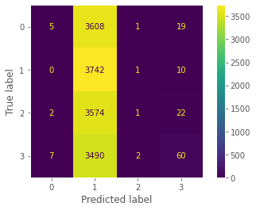

```
=================
Validation Accuracy for Normalized Model :
Resubstitution acc: 0.7307216282187919
Validation acc: 0.7262788778877888
Precision Score: 0.7317640894077239
Recall Score: 0.7262788778877888
F1 Score: 0.7280385983612554
Model error: 0.2737211221122112
```

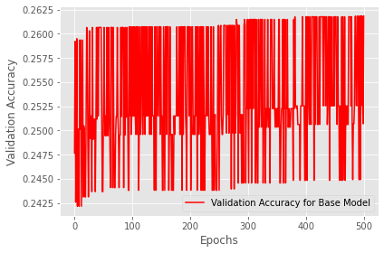

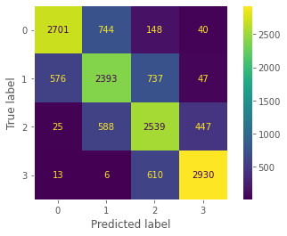

```
=================
Validation Accuracy for Normalized and OHE Model :
Resubstitution acc: 0.7360848489015711
Validation acc: 0.7299917491749175
Precision Score: 0.7322317166279486
Recall Score: 0.7299917491749175
F1 Score: 0.7306424347985838
Model error: 0.2700082508250825
```

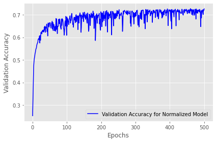

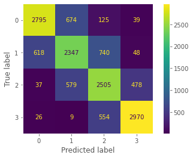

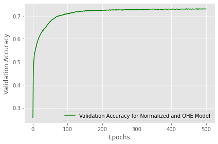

```python
# show results of all three models
print_result(model_base, X_train_base, y_train, X_test_base, y_test, title="Validation Accuracy for Base Model", color="red")
print_result(model_normalized, X_train_normalized, y_train, X_test_normalized, y_test, title="Validation Accuracy for Normalized Model", color="blue")
print_result(model_ohe, X_train, y_train, X_test, y_test, title="Validation Accuracy for Normalized and OHE Model", color="green")
```

> [1 points] Add support for a third layer in the multi-layer perceptron. Add support for saving (and plotting after training is completed) the average magnitude of the gradient for each layer, for each epoch (like we did in the flipped module for back propagation). For magnitude calculation, you are free to use either the average absolute values or the L1/L2 norm.

In the following sections, much like above with the two layer network, I adapt the code (mostly code from lecture) and modify accordingly to implement a multilayer network. This multilayer network can be modified by the user by modifying values n_layers (number of layers) and n_hidden (a list of the number of hidden neurons per layer). Note: the n_layers should be the same value as the length of n_hidden or else the model will not work.

I note changes I have made to each function I changed. Instead of manually creating a specific class for a 3 layer network, I implemented for loops to iterate through each layer to update the weights and biases. A, Z, W, b, and the resepctive grads of W and b will all be held in a matrix - each will be a matrix of matrices where each inner matrix represents the values at that layer (mostly). Later variables like V (sensitivity, not AdaM) have it reversed where the first index is the last layer in the V matrix, as opposed to, for example, the W matrix which the first index corresponds to the first layer and so on.

```python
class MultiLayerPerceptron():
    def __init__(self, n_layers=3, n_hidden=[50,30], C=0.0, epochs=500, eta=0.001, random_state=None):
        np.random.seed(random_state)
        self.n_layers = n_layers  # new parameter for dynamic neural networks
        self.n_hidden = n_hidden
        self.l2_C = C
        self.epochs = epochs
        self.eta = eta

    @staticmethod
    def _encode_labels(y):
        """Encode labels into one-hot representation"""
        onehot = pd.get_dummies(y).values.T

        return onehot

    def _initialize_weights(self):
        """
        Initialize weights with small random numbers.
        Changes made:
            Created empty list to store W and b
            Idea is to be dynamic via n_layers by storing all initialized W and b
            as a list in each list
            Last W must be configured with the last output number of neurons,
            hence not part of the loop
        """
        # initialize an empty list to store all initialized weights
        All_W = []

        # initialize an empty list to store all initialized biases (should all be 1)
        All_b = []

        # initialize first layer W
        W_num_elems = (self.n_features_)*self.n_hidden[0]
        W_first = np.random.uniform(-1.0, 1.0, size=W_num_elems)
        W_first = W_first.reshape(self.n_hidden[0], self.n_features_) # reshape to be W

        All_W.append(W_first)

        # initialize first layer b
        b_first = np.zeros((self.n_hidden[0], 1))

        All_b.append(b_first)

        # iterate through layers
        for layer in range(self.n_layers - 2):  # -2 because we already have 1st and last layer
            W_num_elems = (self.n_hidden[layer])*self.n_hidden[layer + 1]
            W = np.random.uniform(-1.0, 1.0, size=W_num_elems)
            W = W.reshape(self.n_hidden[layer + 1], self.n_hidden[layer]) # reshape to be W
            b = np.zeros((self.n_hidden[layer + 1], 1))

            # append W and b
            All_W.append(W)
            All_b.append(b)

        # intialize last layer
        W_last_num_elems = (self.n_hidden[-1])*self.n_output_
        W_last = np.random.uniform(-1.0, 1.0, size=W_last_num_elems)
        W_last = W_last.reshape(self.n_output_, self.n_hidden[-1])
        b_last = np.zeros((self.n_output_, 1))

        All_W.append(W_last)
        All_b.append(b_last)

        return All_W, All_b

    @staticmethod
    def _sigmoid(z):
        """Use scipy.special.expit to avoid overflow"""
        # 1.0 / (1.0 + np.exp(-z))
        return expit(z)


    @staticmethod
    def _L2_reg(lambda_, W):
        """
        Compute L2-regularization cost
        Changes made:
            For L2, we now need to take the summation of all
            W now that we have a dynamic network
        """

        # iterate through each weight and find sum square
        total_weight = 0
        for weight in W:
            total_weight += np.mean(weight[:, 1:] ** 2)

        # only compute for non-bias terms
        return (lambda_/2.0) * np.sqrt(total_weight)

    def _cost(self, A_last, Y_enc, W):
        '''
        Get the objective function value
        Changes made:
            Need to pass through W as W can be dynamic
            depending on size of network
            Renamed A3 to A_last for consistency
        '''
        cost = np.mean((Y_enc-A_last)**2)
        L2_term = self._L2_reg(self.l2_C, W)
        return cost + L2_term

    def _feedforward(self, X, W, b):
        """Compute feedforward step
        -----------
        X : Input layer with original features.

        W: Weight matrix of matrix for all layers
            1st matrix = first layer -> hidden layer1
            2nd matrix = hidden layer1 -> hidden layer2
            ...etc

        b: bias matrix of matrix for all layers
            1st matrix = first layer -> hidden layer1
            2nd matrix = hidden layer1 -> hidden layer2
            ...etc
        ----------
        A: Activations matrix by each layer
        Z: Layer inputs matrix by each layer

        """
        # initialize list of A and Z to store each layer A and Z
        A = []
        Z = []

        # first layer A - store it
        A_first = X.T
        A.append(A_first)

        # iterate through layers
        for layer in range(self.n_layers - 1):  # once again, need to skip the last layer
            # calculate Z
            Z_layer = W[layer] @ A[layer] + b[layer]
            Z.append(Z_layer)

            # calculate A
            A_layer = self._sigmoid(Z_layer)
            A.append(A_layer)


        # last layer Z
        Z_last = W[self.n_layers - 1] @ A[self.n_layers - 1] + b[self.n_layers - 1]
        Z.append(Z_last)

        # last layer A
        A_last = self._sigmoid(Z_last)
        A.append(A_last)

        return A, Z

    def _get_gradient(self, A, Z, Y_enc, W):
        """
        Compute gradient step using backpropagation
        Changes made:
            Added V, which is the master list of all V to store
            Added grad_w, which is the master list of all grad for w to store
            Added grad_b, which is the master list of all grade for b to store
        """
        # initialize master lists
        V = []
        grad_W = []
        grad_b = []

        # calculate the last layer V, W, b
        V_last = -2*(Y_enc-A[-1])*A[-1]*(1-A[-1])
        gradW_last = V_last @ A[-2].T
        gradb_last = np.sum(V_last, axis=1).reshape((-1,1))

        # append last V, W, b
        V.append(V_last)
        grad_W.append(gradW_last)
        grad_b.append(gradb_last)

        # iterate through layers
        # need to reverse because it back propogates
        # also need to go from last layer to 1st layer (0 isn't a layer)
        for layer in reversed(range(1, self.n_layers)):
            V_idx = abs(layer - self.n_layers + 1)

            # update V
            V_layer = A[layer] * (1 - A[layer]) * (W[layer].T @ V[V_idx])
            V.append(V_layer)

            # update W
            gradW_layer = V[V_idx + 1] @ A[layer-1].T

            # regularize weights that are not bias terms
            gradW_layer += W[layer-1] * self.l2_C
            grad_W.insert(0, gradW_layer)

            # update b
            gradb_layer = np.sum(V[V_idx + 1], axis=1).reshape((-1,1))
            grad_b.insert(0, gradb_layer)

        return grad_W, grad_b

    def predict(self, X):
        """Predict class labels"""
        A, Z = self._feedforward(X, self.W, self.b)
        y_pred = np.argmax(A[self.n_layers], axis=0)
        return y_pred
```

```python
class MLPMiniBatch(MultiLayerPerceptron):
    def __init__(self, alpha=0.0, decrease_const=0.0, shuffle=True, minibatches=1, **kwds):

        # need to add to the original initializer
        self.alpha = alpha
        self.decrease_const = decrease_const
        self.shuffle = shuffle
        self.minibatches = minibatches

        # but keep other keywords
        super().__init__(**kwds)


    def fit(self, X, y, print_progress=False, XY_test=None):
        """ Learn weights from training data. With mini-batch"""
        X_data, y_data = X.copy(), y.copy()
        Y_enc = self._encode_labels(y)

        # init weights and setup matrices
        self.n_features_ = X_data.shape[1]
        self.n_output_ = Y_enc.shape[0]
        self.W, self.b = self._initialize_weights()

        # start momentum at zero for previous updates
        rho_W = []
        rho_W_prev = []
        rho_b = []
        rho_b_prev = []

        # iterate through layers and initialize momentum
        for layer in range(self.n_layers):
            rho_W.append(np.zeros(self.W[layer].shape))
            rho_W_prev.append(np.zeros(self.W[layer].shape))
            rho_b.append(np.zeros(self.b[layer].shape))
            rho_b_prev.append(np.zeros(self.b[layer].shape))

        self.cost_ = []
        self.score_ = []
        # get starting acc
        self.score_.append(accuracy_score(y_data,self.predict(X_data)))
        # keep track of validation, if given
        # provide tuple of this
        # this tracks the health of validation
        if XY_test is not None:
            X_test = XY_test[0].copy()
            y_test = XY_test[1].copy()
            self.val_score_ = []
            self.val_score_.append(accuracy_score(y_test,self.predict(X_test)))

        for i in range(self.epochs):

            # adaptive learning rate
            eta = self.eta / (1 + self.decrease_const*i)

            if print_progress>0 and (i+1)%print_progress==0:
                sys.stderr.write('\rEpoch: %d/%d' % (i+1, self.epochs))
                sys.stderr.flush()

            if self.shuffle:
                idx_shuffle = np.random.permutation(y_data.shape[0])
                X_data, Y_enc, y_data = X_data[idx_shuffle], Y_enc[:, idx_shuffle], y_data[idx_shuffle]

            mini = np.array_split(range(y_data.shape[0]), self.minibatches)
            mini_cost = []
            for idx in mini:

                # feedforward - changed here because function changed in inherited class
                A, Z = self._feedforward(X_data[idx], self.W, self.b)

                # calculate cose - changed here because function changed above
                cost = self._cost(A[-1],Y_enc[:, idx], self.W)
                mini_cost.append(cost) # this appends cost of mini-batch only

                # compute gradient via backpropagation
                grad_W, grad_b = self._get_gradient(A=A, Z=Z, Y_enc=Y_enc[:, idx], W=self.W)

                # iterate through the network
                for layer in range(self.n_layers):

                    # momentum calculations
                    rho_W[layer] = eta * grad_W[layer]
                    rho_b[layer] = eta * grad_b[layer]
                    self.W[layer] -= (rho_W[layer] + (self.alpha * rho_W_prev[layer])) # update with momentum
                    self.b[layer] -= (rho_b[layer] + (self.alpha * rho_b_prev[layer]))
                    rho_W_prev[layer] = rho_W[layer]
                    rho_b_prev[layer] = rho_b[layer]

            self.cost_.append(mini_cost)
            self.score_.append(accuracy_score(y_data,self.predict(X_data)))

            # calculate the validation accuracy
            if XY_test is not None:
                self.val_score_.append(accuracy_score(y_test,self.predict(X_test)))

        return self
```

Note: below parameters include 2 hidden neuron parameters. Following my rule, I take 2/3 of the inputer layer + the size of the output layer as my first hidden layer size. I then reduce this by half as my second layer. This is my general rule of thumb to take between 75% and 50% of the previous layer size.

```python
# parameters to pass through each model - taken from class lecture
n_hidden = round(X_train.shape[1] * 2/3 + 4)
n_hidden2 = round(n_hidden/2)
mlp_vals = {'C':0.01, 'epochs':500, 'eta':0.0001, 'alpha':0.001,
        'decrease_const':1e-5, 'minibatches':100, 'shuffle':True,'random_state':1}

# initialize mlp model
model_mlp3 = MLPMiniBatch(n_layers=3, n_hidden=[n_hidden,n_hidden2], **mlp_vals)

# fit normalized model
model_mlp3.fit(X_train, y_train, print_progress=1, XY_test=(X_test, y_test))
```

```
Epoch: 500/500
```

```
<__main__.MLPMiniBatch at 0x2ca59438520>
```

We calculate the average cost just to see if the model is converging. Which it appears to be converging well. This wasn't a requirement per the assignment, but a health check to see if implementing my approach to a dynamic layer network works. Compared to the first model we made in this exercise, the cost smooths out at around 300 epochs and the cost is significantly smaller. The reduction in cost is also a large reduction by ~50%. This tells me that a 3 layer model with the parameters set above would train nicely at around 300 epochs.

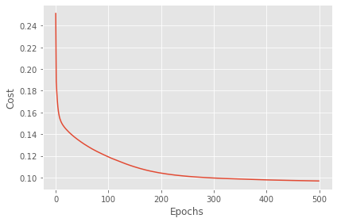

```python
# calculate the average cost
avg_cost = np.average(model_mlp3.cost_, axis=1)

# plot cost function by epochs
plt.plot(range(len(model_mlp3.cost_)), avg_cost)
plt.ylabel('Cost')
plt.xlabel('Epochs')
plt.tight_layout()
plt.show()
```

```python
class MLPMiniBatchCrossEntropy(MLPMiniBatch):
    def _cost(self, A, Y_enc, W):
        '''
        Get the objective function value
        Changes made:
            Made dynamic the A parameter to point to last layer
            Corrected l2 parameter signature to take in W instead of individual Ws
        '''
        cost = -np.mean(np.nan_to_num((Y_enc*np.log(A[-1])+(1-Y_enc)*np.log(1-A[-1]))))
        L2_term = self._L2_reg(self.l2_C, W)
        return cost + L2_term

    def _cost(self, A_last, Y_enc, W):
        '''
        Get the objective function value
        Changes made:
            Need to pass through W as W can be dynamic
            depending on size of network
            Renamed A3 to A_last for consistency
        '''
        cost = np.mean((Y_enc-A_last)**2)
        L2_term = self._L2_reg(self.l2_C, W)
        return cost + L2_term

    def _get_gradient(self, A, Z, Y_enc, W):
        """
        Compute gradient step using backpropagation.
        Changes made:
            Changed V_last to be A[last layer] - Y_enc
        """
        # initialize master lists
        V = []
        grad_W = []
        grad_b = []

        # calculate the last layer V, W, b
        V_last = (A[-1] - Y_enc)
        gradW_last = V_last @ A[-2].T
        gradb_last = np.sum(V_last, axis=1).reshape((-1,1))

        # append last V, W, b
        V.append(V_last)
        grad_W.append(gradW_last)
        grad_b.append(gradb_last)

        # iterate through layers
        # need to reverse because it back propogates
        # also need to go from last layer to 1st layer (0 isn't a layer)
        for layer in reversed(range(1, self.n_layers)):
            V_idx = abs(layer - self.n_layers + 1)

            # update V
            V_layer = A[layer] * (1 - A[layer]) * (W[layer].T @ V[V_idx])
            V.append(V_layer)

            # update W
            gradW_layer = V[V_idx + 1] @ A[layer-1].T

            # regularize weights that are not bias terms
            gradW_layer += W[layer-1] * self.l2_C
            grad_W.insert(0, gradW_layer)

            # update b
            gradb_layer = np.sum(V[V_idx + 1], axis=1).reshape((-1,1))
            grad_b.insert(0, gradb_layer)

        return grad_W, grad_b
```

```python
# initialize mlp model
model_mlp3 = MLPMiniBatchCrossEntropy(n_layers=3, n_hidden=[n_hidden,n_hidden2], **mlp_vals)

# fit normalized model
model_mlp3.fit(X_train, y_train, print_progress=1, XY_test=(X_test, y_test))
```

```
Epoch: 500/500
```

```
<__main__.MLPMiniBatchCrossEntropy at 0x2ca5929b1f0>
```

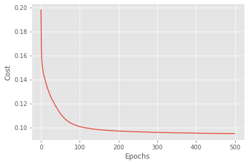

```python
# calculate the average cost
avg_cost = np.average(model_mlp3.cost_, axis=1)

# plot cost function by epochs
plt.plot(range(len(model_mlp3.cost_)), avg_cost)
plt.ylabel('Cost')
plt.xlabel('Epochs')
plt.tight_layout()
plt.show()
```

```python
class MLPBetterInitial(MLPMiniBatchCrossEntropy):
    def _initialize_weights(self):
        """Initialize weights Glorot and He normalization."""
        # initialize empty list to store all weights
        All_W = []

        # initialize empty list to store all bias
        All_b = []

        # initialize first layer weights with Glorot and He normalization
        init_bound = 4*np.sqrt(6. / (self.n_hidden[0] + self.n_features_))
        W_first = np.random.uniform(-init_bound, init_bound,(self.n_hidden[0], self.n_features_))

        # append to master W
        All_W.append(W_first)

        # initialize first layer bias
        b_first = np.zeros((self.n_hidden[0], 1))

        # append to master b
        All_b.append(b_first)

        # iterate through the layers
        for layer in range(self.n_layers - 2):  # Subtract 2 because we are skipping 1st and last layer

            # initialize hidden layer weights
            init_bound = 4*np.sqrt(6. / (self.n_hidden[layer + 1] + self.n_hidden[layer]))
            W_mid = np.random.uniform(-init_bound, init_bound,(self.n_hidden[layer + 1], self.n_hidden[layer]))
            All_W.append(W_mid)

            # initialize hidden layer bias
            b_mid = np.zeros((self.n_hidden[layer + 1], 1))
            All_b.append(b_mid)

        # reduce the final layer magnitude in order to balance the size of the gradients
        # between
        last_bound = 4*np.sqrt(6 / (self.n_output_ + self.n_hidden[-1]))
        W_last = np.random.uniform(-last_bound, last_bound,(self.n_output_, self.n_hidden[-1]))

        # append to master W
        All_W.append(W_last)

        # finalize bias
        b_last = np.zeros((self.n_output_, 1))
        All_b.append(b_last)

        return All_W, All_b
```

```python
# initialize mlp model
model_mlp3 = MLPBetterInitial(n_layers=3, n_hidden=[n_hidden,n_hidden2], **mlp_vals)

# fit normalized model
model_mlp3.fit(X_train, y_train, print_progress=1, XY_test=(X_test, y_test))
```

```
Epoch: 500/500
```

```
<__main__.MLPBetterInitial at 0x2ca56d234c0>
```

> [1 points] Repeat the previous step, adding support for a fourth layer.

The beautiful thing about this implementation is the ability to plug in new parameters without creating new code

```python
# initialize mlp model
n_hidden3 = round(n_hidden2/2)
model_mlp4 = MLPBetterInitial(n_layers=4, n_hidden=[n_hidden,n_hidden2,n_hidden3], **mlp_vals)

# fit normalized model
model_mlp4.fit(X_train, y_train, print_progress=1, XY_test=(X_test, y_test))
```

```
Epoch: 500/500
```

```
<__main__.MLPBetterInitial at 0x2ca56d23190>
```

> [1 points] Repeat the previous step, adding support for a fifth layer.

```python
# initialize mlp model
n_hidden4 = round(n_hidden3/2)
model_mlp5 = MLPBetterInitial(n_layers=5, n_hidden=[n_hidden,n_hidden2,n_hidden3,n_hidden4], **mlp_vals)

# fit normalized model
model_mlp5.fit(X_train, y_train, print_progress=1, XY_test=(X_test, y_test))
```

```
Epoch: 500/500
```

```
<__main__.MLPBetterInitial at 0x2ca56d230a0>
```

There is almost no discernable differences between any of the layered models. We can see common themes between all three: slight overfitting as redistribution accuracy > validation accuracy and similar F1 scores - which means each model consistently predicts each class fairly.

```
=================
Validation Accuracy for MLP 3 Layer :
Resubstitution acc: 0.7458830405335717
Validation acc: 0.7331545654565457
Precision Score: 0.7329369971202268
Recall Score: 0.7331545654565457
F1 Score: 0.7326985706118747
Model error: 0.26684543454345433
```

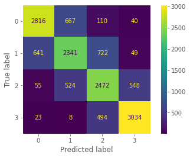

```
=================
Validation Accuracy for MLP 4 Layer :
Resubstitution acc: 0.7471722762746243
Validation acc: 0.7352172717271728
Precision Score: 0.7376244325277245
Recall Score: 0.7352172717271728
F1 Score: 0.7360404631080626
Model error: 0.26478272827282723
```

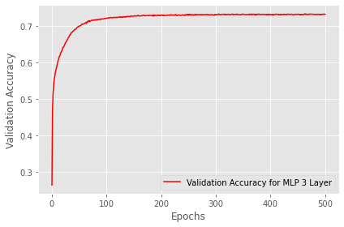

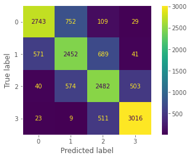

```
=================
Validation Accuracy for MLP 5 Layer :
Resubstitution acc: 0.7484787018255578
Validation acc: 0.7297167216721672
Precision Score: 0.7304103432327306
Recall Score: 0.7297167216721672
F1 Score: 0.7299839939162832
Model error: 0.27028327832783283
```

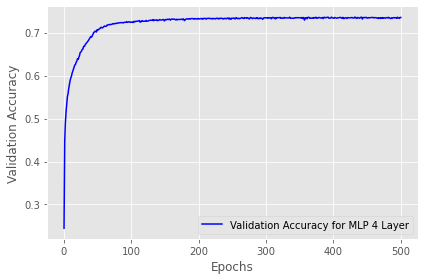

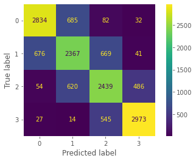

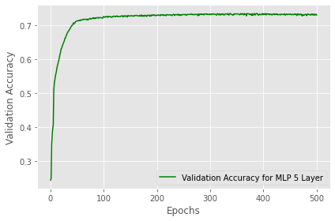

```python
print_result(model_mlp3, X_train, y_train, X_test, y_test, title="Validation Accuracy for MLP 3 Layer", color="red")
print_result(model_mlp4, X_train, y_train, X_test, y_test, title="Validation Accuracy for MLP 4 Layer", color="blue")
print_result(model_mlp5, X_train, y_train, X_test, y_test, title="Validation Accuracy for MLP 5 Layer", color="green")
```

> [2 points] Implement an adaptive learning technique that was discussed in lecture and use it on the five layer network (such as AdaGrad, RMSProps, or AdaDelta). Discuss which adaptive method you chose. Compare the performance of your five layer model with and without the adaptive learning strategy. Do not use AdaM for the adaptive learning technique as it is part of the exceptional work.

> Exceptional Work (1 points total) 5000 level student: You have free reign to provide additional analyses. One idea (required for 7000 level students): Implement adaptive momentum (AdaM) in the five layer neural network and quantify the performance.

I decided to implement all methods, including AdaM in the same block of code. I'm not trying to show off, it was just convenient to start with implementing AdaGrad and having the 3 other optimizers be just one more step of implementation per the previous optimzer (AdaGrad -> RMSProp -> AdaDelta -> AdaM). In fact, this way of implementing has taught me the real differences in the math, as opposed to reading TensorFlow documentation and guessing which one would be best for my model.

One thing I'd like to note is my implementation of V and M. The equation calls for a parameter called gamma. I used beta1 because of 2 ideas I found while researching: 1. gamma is typically 0.9, which beta1 is also typically 0.9, and 2. I've seen some documentations use beta as a term instead of gamma as the term. So, I'm not sure if beta1 is supposed to be used in place of gamma, but I did anyways. In a real production supported scenario, we would use gamma.

```python
class MLPAdaptiveLearning(MLPBetterInitial):
    def __init__(self, beta1=0.9, beta2=0.999, epsilon=1e-8, optimizer="RMSProp", **kwds):

        # need to add to the original initializer
        self.beta1 = beta1
        self.beta2 = beta2
        self.epsilon = epsilon
        self.optimizer = optimizer

        # but keep other keywords
        super().__init__(**kwds)


    def fit(self, X, y, print_progress=False, XY_test=None):
        """ Learn weights from training data. With mini-batch"""
        X_data, y_data = X.copy(), y.copy()
        Y_enc = self._encode_labels(y)

        # init weights and setup matrices
        self.n_features_ = X_data.shape[1]
        self.n_output_ = Y_enc.shape[0]
        self.W, self.b = self._initialize_weights()

        # start momentum at zero for previous updates
        rho_W = []
        rho_W_prev = []
        rho_b = []
        rho_b_prev = []
        g = []
        g_prev = []
        v = []
        v_prev = []
        m = []
        m_prev = []
        m_hat = []
        v_hat = []

        # iterate through layers and initialize momentum
        for layer in range(self.n_layers):
            rho_W.append(np.zeros(self.W[layer].shape))
            rho_W_prev.append(np.zeros(self.W[layer].shape))
            rho_b.append(np.zeros(self.b[layer].shape))
            rho_b_prev.append(np.zeros(self.b[layer].shape))
            g.append(np.zeros(self.W[layer].shape))
            g_prev.append(np.zeros(self.W[layer].shape))
            v.append(np.zeros(self.W[layer].shape))
            v_prev.append(np.zeros(self.W[layer].shape))
            m.append(np.zeros(self.W[layer].shape))
            m_prev.append(np.zeros(self.W[layer].shape))
            m_hat.append(np.zeros(self.W[layer].shape))
            v_hat.append(np.zeros(self.W[layer].shape))

        self.cost_ = []
        self.score_ = []
        # get starting acc
        self.score_.append(accuracy_score(y_data,self.predict(X_data)))
        # keep track of validation, if given
        # provide tuple of this
        # this tracks the health of validation
        if XY_test is not None:
            X_test = XY_test[0].copy()
            y_test = XY_test[1].copy()
            self.val_score_ = []
            self.val_score_.append(accuracy_score(y_test,self.predict(X_test)))

        for i in range(self.epochs):

            # adaptive learning rate
            eta = self.eta / (1 + self.decrease_const*i)

            if print_progress>0 and (i+1)%print_progress==0:
                sys.stderr.write('\rEpoch: %d/%d' % (i+1, self.epochs))
                sys.stderr.flush()

            if self.shuffle:
                idx_shuffle = np.random.permutation(y_data.shape[0])
                X_data, Y_enc, y_data = X_data[idx_shuffle], Y_enc[:, idx_shuffle], y_data[idx_shuffle]

            mini = np.array_split(range(y_data.shape[0]), self.minibatches)
            mini_cost = []
            for j, idx in enumerate(mini):

                # feedforward - changed here because function changed in inherited class
                A, Z = self._feedforward(X_data[idx], self.W, self.b)

                # calculate cose - changed here because function changed above
                cost = self._cost(A[-1],Y_enc[:, idx], self.W)
                mini_cost.append(cost) # this appends cost of mini-batch only

                # compute gradient via backpropagation
                grad_W, grad_b = self._get_gradient(A=A, Z=Z, Y_enc=Y_enc[:, idx], W=self.W)

                # iterate through the network
                for layer in range(self.n_layers):

                    # update W based on optimizer
                    if self.optimizer == "AdaGrad":

                        # momentum calculations AdaGrad
                        g[layer] = self.beta1 * g_prev[layer] + (grad_W[layer] ** 2)
                        rho_W[layer] = 1/np.sqrt(g[layer] + self.epsilon) * grad_W[layer]

                    if self.optimizer == "RMSProp":

                        # momentum calculations RMSProp
                        g[layer] = (grad_W[layer] ** 2)
                        v[layer] = self.beta1 * v_prev[layer] + (1 - self.beta1) * g[layer]
                        rho_W[layer] = 1/np.sqrt(v[layer] + self.epsilon) * grad_W[layer]

                    if self.optimizer == "AdaDelta":

                        # momentum calculations AdaDelta
                        g[layer] = (grad_W[layer] ** 2)
                        v[layer] = self.beta1 * v_prev[layer] + (1 - self.beta1) * g[layer]
                        m[layer] = self.beta1 * m_prev[layer] + (1 - self.beta1) * grad_W[layer]
                        rho_W[layer] = 1/np.sqrt(v[layer] + self.epsilon) * m[layer]

                    if self.optimizer == "AdaM":
                        # momentum calculations AdaM
                        g[layer] = (grad_W[layer] ** 2)
                        m[layer] = self.beta1 * m_prev[layer] + (1 - self.beta1) * grad_W[layer]
                        v[layer] = self.beta2 * v_prev[layer] + (1 - self.beta2) * g[layer]
                        m_hat[layer] = m[layer]/(1 - self.beta1**(layer+1))
                        v_hat[layer] = v[layer]/(1 - self.beta2**(layer+1))
                        rho_W[layer] = m_hat[layer]/np.sqrt(v_hat[layer] + self.epsilon)

                    # update bias momentum
                    rho_b[layer] = eta * grad_b[layer]

                    # update weights and bias
                    self.W[layer] -= (eta * rho_W[layer])
                    self.b[layer] -= (rho_b[layer] + (self.alpha * rho_b_prev[layer]))
                    rho_W_prev[layer] = rho_W[layer]
                    rho_b_prev[layer] = rho_b[layer]
                    g_prev[layer] = g[layer]
                    v_prev[layer] = v[layer]
                    m_prev[layer] = m[layer]

            self.cost_.append(mini_cost)
            self.score_.append(accuracy_score(y_data,self.predict(X_data)))

            # calculate the validation accuracy
            if XY_test is not None:
                self.val_score_.append(accuracy_score(y_test,self.predict(X_test)))

        return self
```

```python
# initialize mlp model
model_adagrad = MLPAdaptiveLearning(n_layers=5, n_hidden=[n_hidden,n_hidden2,n_hidden3,n_hidden4], optimizer="AdaGrad", **mlp_vals)

# fit normalized model
model_adagrad.fit(X_train, y_train, print_progress=1, XY_test=(X_test, y_test))
```

```
Epoch: 500/500
```

```
<__main__.MLPAdaptiveLearning at 0x2ca5bf30e80>
```

```python
# initialize mlp model
model_rms = MLPAdaptiveLearning(n_layers=5, n_hidden=[n_hidden,n_hidden2,n_hidden3,n_hidden4], optimizer="RMSProp", **mlp_vals)

# fit normalized model
model_rms.fit(X_train, y_train, print_progress=1, XY_test=(X_test, y_test))
```

```
Epoch: 500/500
```

```
<__main__.MLPAdaptiveLearning at 0x2ca5bf30d30>
```

```python
# initialize mlp model
model_adadelta = MLPAdaptiveLearning(n_layers=5, n_hidden=[n_hidden,n_hidden2,n_hidden3,n_hidden4], optimizer="AdaDelta", **mlp_vals)

# fit normalized model
model_adadelta.fit(X_train, y_train, print_progress=1, XY_test=(X_test, y_test))
```

```
Epoch: 500/500
```

```
<__main__.MLPAdaptiveLearning at 0x2ca56d236d0>
```

```python
# initialize mlp model
model_adam = MLPAdaptiveLearning(n_layers=5, n_hidden=[n_hidden,n_hidden2,n_hidden3,n_hidden4], optimizer="AdaM", **mlp_vals)

# fit normalized model
model_adam.fit(X_train, y_train, print_progress=1, XY_test=(X_test, y_test))
```

```
Epoch: 500/500
```

```
<__main__.MLPAdaptiveLearning at 0x2ca5bf2d850>
```

Surprisingly, there is not much difference between these models and the previous non adaptive learning models. The same story applies:

```
- There are good accuracies for each model
- Each F1 score is decent, not great, not bad, but decent
- Every model tends to slightly overfit, but by a negligible amount
- The only difference is the number of epochs taken to train each model
```

From these conclusions, I am unable to say which model is the best model. I am unable to preform a McNemar test as I did not implement cross folds - only minibatches which are not the same. From the F1 scores to the similar distribution patters within the confusion matrix, I am unable to provide a best model.

```
=================
Validation Accuracy for MLP AdaGrad Layer :
Resubstitution acc: 0.7345549558221887
Validation acc: 0.7253850385038504
Precision Score: 0.7251696914352486
Recall Score: 0.7253850385038504
F1 Score: 0.7251575547268022
Model error: 0.2746149614961496
```

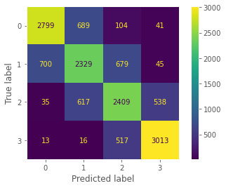

[output not shown]

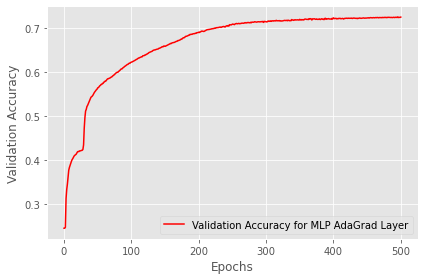

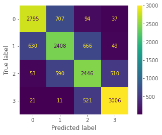

[output not shown]

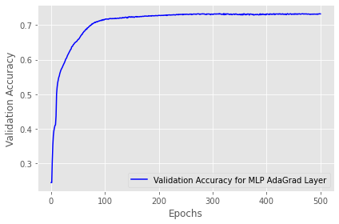

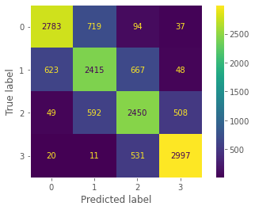

```
=================
Validation Accuracy for MLP AdaM Layer :
Resubstitution acc: 0.7347784233506377
Validation acc: 0.7281353135313532
Precision Score: 0.7273028548198255
Recall Score: 0.7281353135313532
F1 Score: 0.7274189907647197
Model error: 0.2718646864686468
```

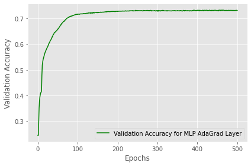

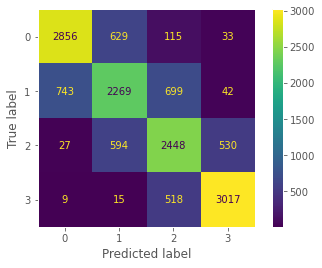

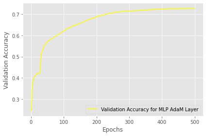

```python
print_result(model_adagrad, X_train, y_train, X_test, y_test, title="Validation Accuracy for MLP AdaGrad Layer", color="red")
print_result(model_rms, X_train, y_train, X_test, y_test, title="Validation Accuracy for MLP AdaGrad Layer", color="blue")
print_result(model_adadelta, X_train, y_train, X_test, y_test, title="Validation Accuracy for MLP AdaGrad Layer", color="green")
print_result(model_adam, X_train, y_train, X_test, y_test, title="Validation Accuracy for MLP AdaM Layer", color="yellow")
```